# TP 4 : Matrices et listes

Introduction au langage R · Cnam · USSI6B-1

Rémi Pierron

17/11/2026

Dépôt GitHub du TP : https://github.com/remipierron/TP4_R

# Partie A

## A1

Création de `A` (remplie par colonne, comportement par défaut) et de `B` (remplie par ligne avec `byrow = TRUE`) :

```r
A <- matrix(1:25, nrow = 5)
B <- matrix(1:25, nrow = 5, byrow = TRUE)
A
```

```
##      [,1] [,2] [,3] [,4] [,5]
## [1,]    1    6   11   16   21
## [2,]    2    7   12   17   22
## [3,]    3    8   13   18   23
## [4,]    4    9   14   19   24
## [5,]    5   10   15   20   25
```

```r
B
```

```
##      [,1] [,2] [,3] [,4] [,5]
## [1,]    1    2    3    4    5
## [2,]    6    7    8    9   10
## [3,]   11   12   13   14   15
## [4,]   16   17   18   19   20
## [5,]   21   22   23   24   25
```

Vérification en une seule instruction que `B` est la transposée de `A` :

```r
identical(B, t(A))
```

```
## [1] TRUE
```

`identical()` renvoie `TRUE` : `B` est bien la transposée de `A`. Remplir par ligne revient à remplir par colonne puis à transposer.

Nommage des lignes et des colonnes de `B` :

```r
rownames(B) <- paste0("L", 1:5)
colnames(B) <- paste0("C", 1:5)
B
```

```
##    C1 C2 C3 C4 C5
## L1  1  2  3  4  5
## L2  6  7  8  9 10
## L3 11 12 13 14 15
## L4 16 17 18 19 20
## L5 21 22 23 24 25
```

**a.** La 3<sup>e</sup> colonne de `B` :

```r
B[, 3]
```

```
## L1 L2 L3 L4 L5
##  3  8 13 18 23
```

**b.** Les lignes 1 et 5 de `B` :

```r
B[c(1, 5), ]
```

```
##    C1 C2 C3 C4 C5
## L1  1  2  3  4  5
## L5 21 22 23 24 25
```

**c.** La colonne `C1` de `B`, par son nom, sous forme de matrice :

```r
B[, "C1", drop = FALSE]
```

```
##    C1
## L1  1
## L2  6
## L3 11
## L4 16
## L5 21
```

Sans `drop = FALSE`, `B[, "C1"]` renverrait un simple vecteur nommé ; avec, on garde une matrice 5 × 1.

## A2

`rnorm()` attend l’**écart-type** (`sd`) et non la variance : pour une variance de 10, on prend `sd = sqrt(10)`. On tire 6 × 6 = 36 valeurs.

```r
set.seed(4)
X <- matrix(rnorm(36, mean = 3, sd = sqrt(10)), nrow = 6)
round(X, 2)
```

```
##      [,1]  [,2] [,3] [,4] [,5]  [,6]
## [1,] 3.69 -1.05 4.21 2.68 4.87  3.49
## [2,] 1.28  2.33 2.86 2.10 2.11  6.33
## [3,] 5.82  9.00 3.11 7.87 6.97  0.61
## [4,] 4.88  8.62 3.53 3.52 5.88 -1.69
## [5,] 8.17  4.79 6.68 7.14 0.07  5.72
## [6,] 5.18  3.05 2.86 7.07 6.92  1.72
```

**a.** Nombre d’éléments supérieurs à 3 :

```r
sum(X > 3)
```

```
## [1] 24
```

`X > 3` donne une matrice de `TRUE`/`FALSE`, et `sum()` compte les `TRUE` : **24 éléments** sur 36 sont supérieurs à 3.

**b.** Positions du minimum et du maximum :

```r
pos_min <- which(X == min(X), arr.ind = TRUE)
pos_max <- which(X == max(X), arr.ind = TRUE)
pos_min
```

```
##      row col
## [1,]   4   6
```

```r
pos_max
```

```
##      row col
## [1,]   3   2
```

Le minimum (-1.69) est en ligne 4, colonne 6 ; le maximum (9) est en ligne 3, colonne 2.

**c.** Matrice indicatrice `X01` en une seule instruction :

```r
X01 <- (X > 3) * 1
X01
```

```
##      [,1] [,2] [,3] [,4] [,5] [,6]
## [1,]    1    0    1    0    1    1
## [2,]    0    0    0    0    0    1
## [3,]    1    1    1    1    1    0
## [4,]    1    1    1    1    1    0
## [5,]    1    1    1    1    0    1
## [6,]    1    1    0    1    1    0
```

```r
dim(X01)
```

```
## [1] 6 6
```

```r
is.matrix(X01)
```

```
## [1] TRUE
```

Multiplier la matrice logique `X > 3` par 1 convertit `TRUE` en 1 et `FALSE` en 0, tout en conservant l’attribut `dim` : `X01` est bien une matrice 6 × 6.

## A3

**a.** Sommes des lignes, des colonnes, de la diagonale et de l’anti-diagonale de `durer` :

```r
durer
```

```
##      [,1] [,2] [,3] [,4]
## [1,]   16    3    2   13
## [2,]    5   10   11    8
## [3,]    9    6    7   12
## [4,]    4   15   14    1
```

```r
rowSums(durer)
```

```
## [1] 34 34 34 34
```

```r
colSums(durer)
```

```
## [1] 34 34 34 34
```

```r
sum(diag(durer))
```

```
## [1] 34
```

```r
sum(diag(durer[, ncol(durer):1]))   # anti-diagonale
```

```
## [1] 34
```

Toutes ces sommes valent 34 : le carré de Dürer est magique.

**b.** Une seule instruction qui teste si une matrice est magique : on regroupe toutes les sommes dans un vecteur et on vérifie qu’il n’y a qu’une seule valeur distincte.

```r
magique_durer <- length(unique(c(rowSums(durer), colSums(durer), sum(diag(durer)), sum(diag(durer[, ncol(durer):1]))))) == 1
magique_durer
```

```
## [1] TRUE
```

```r
magique_candidat <- length(unique(c(rowSums(candidat), colSums(candidat), sum(diag(candidat)), sum(diag(candidat[, ncol(candidat):1]))))) == 1
magique_candidat
```

```
## [1] FALSE
```

`durer` est magique (TRUE), `candidat` ne l’est pas (FALSE).

**c.** Diagnostic de `candidat` :

```r
candidat
```

```
##      [,1] [,2] [,3]
## [1,]    8    1    6
## [2,]    3    5    7
## [3,]    4    9    3
```

```r
rowSums(candidat)
```

```
## [1] 15 15 16
```

```r
colSums(candidat)
```

```
## [1] 15 15 16
```

```r
sum(diag(candidat))
```

```
## [1] 16
```

```r
sum(diag(candidat[, ncol(candidat):1]))
```

```
## [1] 15
```

La somme attendue est la valeur la plus fréquente parmi les 8 sommes (3 lignes, 3 colonnes, 2 diagonales) :

```r
sommes <- c(rowSums(candidat), colSums(candidat),
            sum(diag(candidat)), sum(diag(candidat[, ncol(candidat):1])))
table(sommes)
```

```
## sommes
## 15 16
##  5  3
```

```r
cible <- as.numeric(names(which.max(table(sommes))))
cible
```

```
## [1] 15
```

La somme la plus fréquente est **15** (5 sommes sur 8) : c’est la cible. Repérons ce qui s’en écarte :

```r
lignes_pb   <- which(rowSums(candidat) != cible)
colonnes_pb <- which(colSums(candidat) != cible)
lignes_pb
```

```
## [1] 3
```

```r
colonnes_pb
```

```
## [1] 3
```

```r
ecart <- rowSums(candidat)[lignes_pb] - cible
ecart
```

```
## [1] 1
```

Seules la ligne 3, la colonne 3 et la diagonale principale valent 16 au lieu de 15. La case commune à ces trois sommes est la case [3, 3], qui vaut 3 : il faut la diminuer de 1, donc la remplacer par **2**. Vérification :

```r
candidat_corrige <- candidat
candidat_corrige[lignes_pb, colonnes_pb] <- candidat[lignes_pb, colonnes_pb] - ecart
candidat_corrige
```

```
##      [,1] [,2] [,3]
## [1,]    8    1    6
## [2,]    3    5    7
## [3,]    4    9    2
```

```r
length(unique(c(rowSums(candidat_corrige), colSums(candidat_corrige), sum(diag(candidat_corrige)), sum(diag(candidat_corrige[, ncol(candidat_corrige):1]))))) == 1
```

```
## [1] TRUE
```

Après correction, `candidat` devient magique (et contient bien les entiers de 1 à 9).

## A4

`outer(1:10, 1:10)` calcule le produit de toutes les paires $(i, j)$. On nomme les lignes et colonnes pour la lisibilité :

```r
table_mult <- outer(1:10, 1:10)
dimnames(table_mult) <- list(1:10, 1:10)
table_mult
```

```
##     1  2  3  4  5  6  7  8  9  10
## 1   1  2  3  4  5  6  7  8  9  10
## 2   2  4  6  8 10 12 14 16 18  20
## 3   3  6  9 12 15 18 21 24 27  30
## 4   4  8 12 16 20 24 28 32 36  40
## 5   5 10 15 20 25 30 35 40 45  50
## 6   6 12 18 24 30 36 42 48 54  60
## 7   7 14 21 28 35 42 49 56 63  70
## 8   8 16 24 32 40 48 56 64 72  80
## 9   9 18 27 36 45 54 63 72 81  90
## 10 10 20 30 40 50 60 70 80 90 100
```

**a.** Nombre de produits distincts :

```r
length(unique(as.vector(table_mult)))
```

```
## [1] 42
```

La table contient 100 cases mais seulement **42 produits distincts** : beaucoup de valeurs se répètent (par symétrie, $i \times j = j \times i$, et par exemple $12 = 2 \times 6 = 3 \times 4$).

**b.** Proportion de cases contenant un nombre pair :

```r
mean(table_mult %% 2 == 0)
```

```
## [1] 0.75
```

`table_mult %% 2 == 0` est une matrice logique ; sa moyenne donne la proportion de `TRUE`. **75 %** des cases sont paires : un produit n’est impair que si les deux facteurs sont impairs, soit 5 × 5 = 25 cases sur 100.

**c.** Valeurs strictement au-dessus de la diagonale :

```r
upper.tri(table_mult)[1:4, 1:4]   # aperçu du masque logique
```

```
##       [,1]  [,2]  [,3]  [,4]
## [1,] FALSE  TRUE  TRUE  TRUE
## [2,] FALSE FALSE  TRUE  TRUE
## [3,] FALSE FALSE FALSE  TRUE
## [4,] FALSE FALSE FALSE FALSE
```

```r
au_dessus <- table_mult[upper.tri(table_mult)]
au_dessus
```

```
##  [1]  2  3  6  4  8 12  5 10 15 20  6 12 18 24 30  7 14 21 28 35 42  8 16 24 32
## [26] 40 48 56  9 18 27 36 45 54 63 72 10 20 30 40 50 60 70 80 90
```

```r
length(au_dessus)
```

```
## [1] 45
```

`upper.tri()` renvoie une matrice logique valant `TRUE` strictement au-dessus de la diagonale ; elle sert d’index. On obtient **45 valeurs**, soit $(100 - 10) / 2$ : les 100 cases moins les 10 de la diagonale, divisées par deux puisque la table est symétrique.

## A5

```r
dim(volcano)
```

```
## [1] 87 61
```

```r
range(volcano)
```

```
## [1]  94 195
```

**a.** Altitude maximale et position(s) :

```r
max(volcano)
```

```
## [1] 195
```

```r
pos_sommet <- which(volcano == max(volcano), arr.ind = TRUE)
pos_sommet
```

```
##      row col
## [1,]  20  31
```

L’altitude maximale est de **195 m**, atteinte en une seule position : ligne 20, colonne 31.

**b.** Proportion du terrain au-dessus de 150 m :

```r
mean(volcano > 150)
```

```
## [1] 0.2313925
```

Environ **23.1 %** des points de la grille sont à plus de 150 m.

**c.** Ligne d’altitude moyenne la plus élevée :

```r
moy_lignes <- rowMeans(volcano)
which.max(moy_lignes)
```

```
## [1] 22
```

```r
max(moy_lignes)
```

```
## [1] 159.541
```

C’est la **ligne 22**, avec une altitude moyenne de 159.5 m.

**d.** Dénivelé (maximum − minimum) de chaque colonne :

```r
denivele <- apply(volcano, 2, max) - apply(volcano, 2, min)
denivele
```

```
##  [1] 27 31 34 36 38 39 41 43 44 47 49 52 55 58 62 66 68 72 75 78 81 84 86 89 90
## [26] 90 91 92 93 94 95 94 93 92 93 92 93 94 93 93 93 90 89 89 86 86 85 85 81 77
## [51] 68 60 55 48 42 36 30 25 22 19 16
```

```r
which.max(denivele)
```

```
## [1] 31
```

La **colonne 31** a le plus fort dénivelé (95 m) ; c’est aussi la colonne qui contient le sommet.

**e.** Retournement de haut en bas : on inverse l’ordre des lignes.

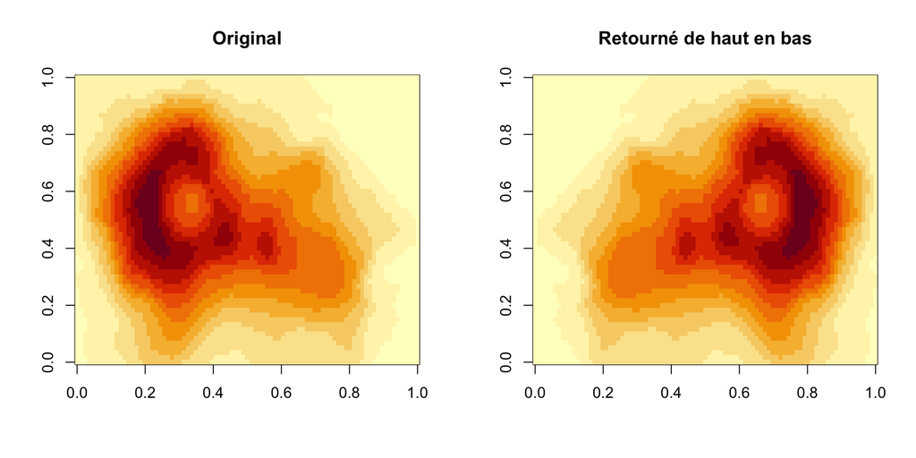

```r
volcano_retourne <- volcano[nrow(volcano):1, ]
par(mfrow = c(1, 2))
image(volcano, main = "Original")
image(volcano_retourne, main = "Retourné de haut en bas")
```

```r
par(mfrow = c(1, 1))
```

Remarque : `image()` place les lignes de la matrice sur l’axe horizontal. Inverser les lignes (retournement « haut-bas » de la matrice) apparaît donc à l’écran comme une symétrie gauche-droite de l’image.

# Partie B

## B1

```r
Q
```

```
##        raquette ballon maillot chaussures
## Lyon        120     80      45         30
## Lille        95    110      60         25
## Nantes      150     70      30         55
```

```r
prix
```

```
##   raquette     ballon    maillot chaussures
##         35         18         40         85
```

```r
cout
```

```
##   raquette     ballon    maillot chaussures
##         21          9         22         51
```

**a.** Chiffre d’affaires de chaque magasin : `Q` (3 × 4) multiplié par le vecteur `prix` (4 éléments) donne une matrice 3 × 1. Chaque ligne est la somme des quantités × prix.

```r
CA_magasin <- Q %*% prix
colnames(CA_magasin) <- "CA"
CA_magasin
```

```
##           CA
## Lyon    9990
## Lille   9830
## Nantes 12385
```

**b.** Marge de chaque magasin : même produit matriciel avec la marge unitaire `prix - cout`.

```r
prix - cout
```

```
##   raquette     ballon    maillot chaussures
##         14          9         18         34
```

```r
marge_magasin <- Q %*% (prix - cout)
colnames(marge_magasin) <- "marge"
marge_magasin
```

```
##        marge
## Lyon    4230
## Lille   4250
## Nantes  5140
```

La marge est de 4230 € à Lyon, 4250 € à Lille et 5140 € à Nantes. Lille a un CA plus faible que Lyon mais une marge légèrement plus élevée.

**c.** CA par magasin et par produit : multiplier `Q` par la matrice diagonale `diag(prix)` multiplie chaque colonne de `Q` par le prix du produit correspondant. `diag()` perd les noms, on les remet.

```r
diag(prix)
```

```
##      [,1] [,2] [,3] [,4]
## [1,]   35    0    0    0
## [2,]    0   18    0    0
## [3,]    0    0   40    0
## [4,]    0    0    0   85
```

```r
CA_detail <- Q %*% diag(prix)
colnames(CA_detail) <- names(prix)
CA_detail
```

```
##        raquette ballon maillot chaussures
## Lyon       4200   1440    1800       2550
## Lille      3325   1980    2400       2125
## Nantes     5250   1260    1200       4675
```

```r
pos_max_CA <- which(CA_detail == max(CA_detail), arr.ind = TRUE)
pos_max_CA
```

```
##        row col
## Nantes   3   1
```

La combinaison la plus rentable est **Nantes × raquette**, avec un CA de 5250 €.

**d.** Vérification : les sommes des lignes redonnent le CA de la question a.

```r
rowSums(CA_detail)
```

```
##   Lyon  Lille Nantes
##   9990   9830  12385
```

```r
all.equal(rowSums(CA_detail), CA_magasin[, "CA"])
```

```
## [1] TRUE
```

`all.equal()` renvoie `TRUE` : la somme du CA par produit redonne bien le CA total de chaque magasin.

## B2

```r
M
```

```
##      [,1] [,2] [,3] [,4]
## [1,]  0.4  0.2  0.1  0.3
## [2,]  0.2  0.4  0.2  0.1
## [3,]  0.3  0.2  0.5  0.2
## [4,]  0.1  0.2  0.2  0.4
```

```r
stock
```

```
## [1] 61 50 76 53
```

Si $x$ est le vecteur des quantités d’aliments à produire, la quantité de céréale $i$ utilisée est $\sum_j M_{ij} x_j$. Utiliser exactement tout le stock revient à résoudre le système $Mx = \text{stock}$.

**a.** Résolution avec `solve(M, b)` :

```r
x <- solve(M, stock)
names(x) <- paste0("aliment", 1:4)
x
```

```
## aliment1 aliment2 aliment3 aliment4
##       70       40       70       60
```

Il faut produire **70 t de l’aliment 1, 40 t de l’aliment 2, 70 t de l’aliment 3 et 60 t de l’aliment 4**.

**b.** Vérification : $Mx$ doit redonner le stock.

```r
M %*% x
```

```
##      [,1]
## [1,]   61
## [2,]   50
## [3,]   76
## [4,]   53
```

```r
all.equal(as.vector(M %*% x), stock)
```

```
## [1] TRUE
```

On retrouve exactement le stock disponible (TRUE) : la solution est correcte.

**c.** On remplace la 4<sup>e</sup> ligne par la somme des lignes 1 et 2 :

```r
M4 <- M
M4[4, ] <- M[1, ] + M[2, ]
M4
```

```
##      [,1] [,2] [,3] [,4]
## [1,]  0.4  0.2  0.1  0.3
## [2,]  0.2  0.4  0.2  0.1
## [3,]  0.3  0.2  0.5  0.2
## [4,]  0.6  0.6  0.3  0.4
```

```r
det(M4)
```

```
## [1] 5.162537e-19
```

```r
solve(M4)
```

```
## Error in `solve.default()`:
## ! system is computationally singular: reciprocal condition number = 3.54814e-18
```

```r
solve(M4, stock)
```

```
## Error in `solve.default()`:
## ! system is computationally singular: reciprocal condition number = 3.54814e-18
```

## B3

```r
P
```

```
##      A    B    C
## A 0.85 0.10 0.05
## B 0.15 0.75 0.10
## C 0.10 0.20 0.70
```

```r
parts0
```

```
##   A   B   C
## 0.5 0.3 0.2
```

**a.** Chaque ligne de `P` doit sommer à 1 :

```r
rowSums(P)
```

```
## A B C
## 1 1 1
```

```r
all(abs(rowSums(P) - 1) < 1e-12)
```

```
## [1] TRUE
```

Toutes les lignes somment à 1 (on compare avec une tolérance, à cause des arrondis en virgule flottante) : `P` est bien une matrice de transition.

**b.** Parts de marché dans 1, 2 et 3 mois : on multiplie à chaque fois par `P`.

```r
parts1 <- parts0 %*% P
parts2 <- parts1 %*% P
parts3 <- parts2 %*% P
evolution <- rbind(parts0, parts1, parts2, parts3)
rownames(evolution) <- paste("mois", 0:3)
round(evolution, 4)
```

```
##             A      B      C
## mois 0 0.5000 0.3000 0.2000
## mois 1 0.4900 0.3150 0.1950
## mois 2 0.4832 0.3242 0.1925
## mois 3 0.4786 0.3300 0.1913
```

L’opérateur A perd des parts (de 50 % à 47.9 % en 3 mois), B en gagne (de 30 % à 33 %) et C baisse légèrement (de 20 % à 19.1 %).

**c.** Parts dans 12 mois : $P^{12} = P^8 \times P^4$, et on obtient $P^2$, $P^4$, $P^8$ par élévations au carré successives.

```r
P2 <- P %*% P
P4 <- P2 %*% P2
P8 <- P4 %*% P4
P12 <- P8 %*% P4
parts12 <- parts0 %*% P12
round(parts12, 4)
```

```
##           A      B      C
## [1,] 0.4686 0.3401 0.1913
```

Dans 12 mois, les parts de marché seraient d’environ **46.9 % pour A, 34 % pour B et 19.1 % pour C**.

**d.** $P^{64}$ par élévations au carré successives ($P^{16}$, $P^{32}$, $P^{64}$) :

```r
P16 <- P8 %*% P8
P32 <- P16 %*% P16
P64 <- P32 %*% P32
round(P64, 6)
```

```
##          A        B        C
## A 0.468085 0.340426 0.191489
## B 0.468085 0.340426 0.191489
## C 0.468085 0.340426 0.191489
```

Les trois lignes de $P^{64}$ sont **identiques**. La ligne $i$ donne la répartition des clients au bout de 64 mois sachant qu’ils étaient au départ chez l’opérateur $i$ : à long terme, cette répartition **ne dépend plus de l’opérateur de départ**. La chaîne converge vers un équilibre où A détient environ 46.8 % du marché, B 34 % et C 19.1 %, quelles que soient les parts initiales.

**e.** Distribution stationnaire avec `eigen()` : on cherche le vecteur propre de $P^\top$ associé à la valeur propre 1, puis on le normalise pour que ses composantes somment à 1.

```r
decomp <- eigen(t(P))
decomp$values
```

```
## [1] 1.0000000 0.7207107 0.5792893
```

```r
v <- decomp$vectors[, which.min(abs(decomp$values - 1))]
pi_stat <- v / sum(v)
names(pi_stat) <- colnames(P)
pi_stat
```

```
##         A         B         C
## 0.4680851 0.3404255 0.1914894
```

```r
pi_stat %*% P                                  # vérification : pi P = pi
```

```
##              A         B         C
## [1,] 0.4680851 0.3404255 0.1914894
```

```r
all.equal(as.vector(P64[1, ]), as.vector(pi_stat))
```

```
## [1] TRUE
```

Vérification de la forme exacte de $\pi$ : multipliée par 47, elle doit donner des entiers.

```r
pi_stat * 47
```

```
##  A  B  C
## 22 16  9
```

```r
all.equal(as.vector(pi_stat), c(22, 16, 9) / 47)
```

```
## [1] TRUE
```

La distribution stationnaire est $\pi \approx$ (0.4681 ; 0.3404 ; 0.1915). `pi_stat * 47` donne (22 ; 16 ; 9) et `all.equal()` renvoie TRUE : $\pi$ vaut exactement (22/47 ; 16/47 ; 9/47). Elle est identique à chacune des lignes de $P^{64}$ (`all.equal()` renvoie `TRUE`) : la question d retrouve numériquement l’équilibre de long terme que `eigen()` donne directement.

# Partie C

## C1

Structure de l’array :

```r
dim(Titanic)
```

```
## [1] 4 2 2 2
```

```r
dimnames(Titanic)
```

```
## $Class
## [1] "1st"  "2nd"  "3rd"  "Crew"
##
## $Sex
## [1] "Male"   "Female"
##
## $Age
## [1] "Child" "Adult"
##
## $Survived
## [1] "No"  "Yes"
```

Nombre total de personnes à bord : on somme toutes les cases de l’array.

```r
total <- sum(Titanic)
total
```

```
## [1] 2201
```

Nombre de personnes par classe : on garde la dimension 1 (`Class`) et on somme sur les autres.

```r
par_classe <- apply(Titanic, 1, sum)
par_classe
```

```
##  1st  2nd  3rd Crew
##  325  285  706  885
```

```r
round(100 * prop.table(par_classe), 1)
```

```
##  1st  2nd  3rd Crew
## 14.8 12.9 32.1 40.2
```

```r
part_equipage <- par_classe["Crew"] / total
part_equipage
```

```
##    Crew
## 0.40209
```

Il y avait **2201 personnes** à bord : 325 en 1<sup>re</sup> classe, 285 en 2<sup>e</sup>, 706 en 3<sup>e</sup> et 885 membres d’équipage. L’équipage représentait **40.2 %** des personnes à bord, soit le groupe le plus nombreux.

## C2

**Taux de survie global** : nombre de survivants (couche `Survived = "Yes"`) divisé par le total.

```r
survie_globale <- 100 * sum(Titanic[, , , "Yes"]) / sum(Titanic)
round(survie_globale, 1)
```

```
## [1] 32.3
```

**Taux de survie par classe** : on agrège en classe × survie, puis `prop.table(..., margin = 1)` divise chaque ligne par son total.

```r
classe_survie <- apply(Titanic, c(1, 4), sum)
classe_survie
```

```
##       Survived
## Class   No Yes
##   1st  122 203
##   2nd  167 118
##   3rd  528 178
##   Crew 673 212
```

```r
survie_classe <- round(100 * prop.table(classe_survie, margin = 1)[, "Yes"], 1)
survie_classe
```

```
##  1st  2nd  3rd Crew
## 62.5 41.4 25.2 24.0
```

**Taux de survie par sexe** : même démarche en gardant les dimensions 2 (sexe) et 4 (survie).

```r
sexe_survie <- apply(Titanic, c(2, 4), sum)
sexe_survie
```

```
##         Survived
## Sex        No Yes
##   Male   1364 367
##   Female  126 344
```

```r
survie_sexe <- round(100 * prop.table(sexe_survie, margin = 1)[, "Yes"], 1)
survie_sexe
```

```
##   Male Female
##   21.2   73.2
```

Globalement, seulement **32.3 %** des personnes à bord ont survécu. Le taux de survie décroît avec la classe : 62.5 % en 1<sup>re</sup>, 41.4 % en 2<sup>e</sup>, 25.2 % en 3<sup>e</sup> et 24 % pour l’équipage. L’écart est encore plus marqué selon le sexe : 73.2 % des femmes ont survécu contre 21.2 % des hommes.

## C3

On agrège en sexe × âge × survie (array 2 × 2 × 2), puis on divise la couche `"Yes"` par la somme des deux couches :

```r
sexe_age_survie <- apply(Titanic, c(2, 3, 4), sum)
sexe_age_survie
```

```
## , , Survived = No
##
##         Age
## Sex      Child Adult
##   Male      35  1329
##   Female    17   109
##
## , , Survived = Yes
##
##         Age
## Sex      Child Adult
##   Male      29   338
##   Female    28   316
```

```r
survie_sexe_age <- 100 * sexe_age_survie[, , "Yes"] /
  (sexe_age_survie[, , "No"] + sexe_age_survie[, , "Yes"])
round(survie_sexe_age, 1)
```

```
##         Age
## Sex      Child Adult
##   Male    45.3  20.3
##   Female  62.2  74.4
```

La règle « les femmes et les enfants d’abord » a été **largement appliquée** : les hommes adultes ont de loin le plus faible taux de survie (20.3 %), contre 74.4 % pour les femmes adultes, 62.2 % pour les filles et 45.3 % pour les garçons. Elle n’a cependant pas été appliquée parfaitement : moins de la moitié des garçons ont survécu, et les filles ont survécu moins souvent que les femmes adultes. Cela s’explique en partie par la classe : la plupart des enfants voyageaient en 3<sup>e</sup> classe (voir C5), où l’accès aux canots était plus difficile.

## C4

Même méthode qu’en C3, en gardant cette fois la classe, le sexe et la survie (array 4 × 2 × 2) :

```r
classe_sexe_survie <- apply(Titanic, c(1, 2, 4), sum)
survie_classe_sexe <- 100 * classe_sexe_survie[, , "Yes"] /
  (classe_sexe_survie[, , "No"] + classe_sexe_survie[, , "Yes"])
round(survie_classe_sexe, 1)
```

```
##       Sex
## Class  Male Female
##   1st  34.4   97.2
##   2nd  14.0   87.7
##   3rd  17.3   45.9
##   Crew 22.3   87.0
```

```r
dim(survie_classe_sexe)
```

```
## [1] 4 2
```

```r
survie_classe_sexe["3rd", "Female"]
```

```
## [1] 45.91837
```

```r
survie_classe_sexe["1st", "Male"]
```

```
## [1] 34.44444
```

Les femmes de 3<sup>e</sup> classe ont survécu à **45.9 %**, contre **34.4 %** pour les hommes de 1<sup>re</sup> classe. Une femme de la classe la plus modeste avait donc plus de chances de survivre qu’un homme de la classe la plus aisée : **le sexe a pesé plus lourd que la classe** dans la survie. La classe joue tout de même un rôle important à sexe égal : 97.2 % des femmes de 1<sup>re</sup> classe ont survécu, soit deux fois plus que celles de 3<sup>e</sup> classe.

## C5

On extrait la sous-partie « enfants » de l’array (`Age = "Child"`), ce qui donne un array classe × sexe × survie, puis on agrège en classe × survie :

```r
enfants <- Titanic[, , "Child", ]
enfants_classe <- apply(enfants, c(1, 3), sum)
enfants_classe
```

```
##       Survived
## Class  No Yes
##   1st   0   6
##   2nd   0  24
##   3rd  52  27
##   Crew  0   0
```

```r
nb_enfants   <- rowSums(enfants_classe)
nb_survivants <- enfants_classe[, "Yes"]
nb_enfants
```

```
##  1st  2nd  3rd Crew
##    6   24   79    0
```

```r
nb_survivants
```

```
##  1st  2nd  3rd Crew
##    6   24   27    0
```

Vérification : tous les enfants de 1<sup>re</sup> et 2<sup>e</sup> classe ont-ils survécu ?

```r
all(enfants_classe[c("1st", "2nd"), "No"] == 0)
```

```
## [1] TRUE
```

Il y avait 109 enfants à bord : 6 en 1<sup>re</sup> classe, 24 en 2<sup>e</sup>, 79 en 3<sup>e</sup> et 0 dans l’équipage (ce qui est logique). Parmi eux, 57 ont survécu : 6 en 1<sup>re</sup>, 24 en 2<sup>e</sup> et seulement 27 en 3<sup>e</sup>. **Oui, tous les enfants de 1<sup>re</sup> et 2<sup>e</sup> classe ont survécu**, alors qu’en 3<sup>e</sup> classe 52 enfants sur 79 sont morts, soit environ 66 %.

## C6

Conversion en data frame :

```r
titanic_df <- as.data.frame(Titanic)
dim(titanic_df)
```

```
## [1] 32  5
```

```r
head(titanic_df, 10)
```

```
##    Class    Sex   Age Survived Freq
## 1    1st   Male Child       No    0
## 2    2nd   Male Child       No    0
## 3    3rd   Male Child       No   35
## 4   Crew   Male Child       No    0
## 5    1st Female Child       No    0
## 6    2nd Female Child       No    0
## 7    3rd Female Child       No   17
## 8   Crew Female Child       No    0
## 9    1st   Male Adult       No  118
## 10   2nd   Male Adult       No  154
```

```r
str(titanic_df)
```

```
## 'data.frame':    32 obs. of  5 variables:
##  $ Class   : Factor w/ 4 levels "1st","2nd","3rd",..: 1 2 3 4 1 2 3 4 1 2 ...
##  $ Sex     : Factor w/ 2 levels "Male","Female": 1 1 1 1 2 2 2 2 1 1 ...
##  $ Age     : Factor w/ 2 levels "Child","Adult": 1 1 1 1 1 1 1 1 2 2 ...
##  $ Survived: Factor w/ 2 levels "No","Yes": 1 1 1 1 1 1 1 1 1 1 ...
##  $ Freq    : num  0 0 35 0 0 0 17 0 118 154 ...
```

On obtient **32 lignes** : une par case de l’array, c’est-à-dire une par combinaison des modalités, soit $4 \times 2 \times 2 \times 2 = 32$. Les quatre dimensions deviennent quatre colonnes (facteurs) et l’effectif de chaque case est stocké dans une cinquième colonne `Freq`. Les combinaisons vides (par exemple les enfants de l’équipage) sont conservées avec `Freq = 0`.

**Avec `xtabs()`** : on reconstruit le tableau classe × survie en sommant `Freq`, puis on calcule les pourcentages par ligne.

```r
tab_xtabs <- xtabs(Freq ~ Class + Survived, data = titanic_df)
tab_xtabs
```

```
##       Survived
## Class   No Yes
##   1st  122 203
##   2nd  167 118
##   3rd  528 178
##   Crew 673 212
```

```r
round(100 * prop.table(tab_xtabs, margin = 1), 1)
```

```
##       Survived
## Class    No  Yes
##   1st  37.5 62.5
##   2nd  58.6 41.4
##   3rd  74.8 25.2
##   Crew 76.0 24.0
```

**Avec `aggregate()`** : on somme `Freq` par classe, pour les survivants puis pour l’ensemble.

```r
survivants <- aggregate(Freq ~ Class, data = titanic_df[titanic_df$Survived == "Yes", ], FUN = sum)
total_classe <- aggregate(Freq ~ Class, data = titanic_df, FUN = sum)
survie_df <- data.frame(Class = total_classe$Class,
                        taux_survie = round(100 * survivants$Freq / total_classe$Freq, 1))
survie_df
```

```
##   Class taux_survie
## 1   1st        62.5
## 2   2nd        41.4
## 3   3rd        25.2
## 4  Crew        24.0
```

Les deux méthodes redonnent exactement les taux de survie par classe de la question C2 (1st : 62.5 %, 2nd : 41.4 %, 3rd : 25.2 %, Crew : 24 %).

# Partie D

## D1

```r
l <- list(a = 1:3, b = "x", c = list(d = TRUE, e = 2.5))
```

**Prédictions** (écrites avant l’exécution) :

| Instruction | Classe prédite | Contenu prédit |
| --- | --- | --- |
| `l[1]` | `list` | une liste d’un seul élément, nommé `a`, qui contient le vecteur `1 2 3` |
| `l[[1]]` | `integer` | le vecteur `1 2 3` lui-même (sorti de la liste) |
| `l$c$e` | `numeric` | la valeur `2.5` |
| `l[["c"]]["d"]` | `list` | une liste d’un élément, nommé `d`, contenant `TRUE` |
| `length(l)` | `integer` | `3` (les éléments `a`, `b`, `c` : la sous-liste compte pour un seul élément) |
| `unlist(l)` | `character` | un vecteur nommé de 6 éléments, tout converti en texte : `"1" "2" "3" "x" "TRUE" "2.5"` |

**Exécution :**

```r
l[1]
```

```
## $a
## [1] 1 2 3
```

```r
class(l[1])
```

```
## [1] "list"
```

```r
l[[1]]
```

```
## [1] 1 2 3
```

```r
class(l[[1]])
```

```
## [1] "integer"
```

```r
l$c$e
```

```
## [1] 2.5
```

```r
class(l$c$e)
```

```
## [1] "numeric"
```

```r
l[["c"]]["d"]
```

```
## $d
## [1] TRUE
```

```r
class(l[["c"]]["d"])
```

```
## [1] "list"
```

```r
length(l)
```

```
## [1] 3
```

```r
class(length(l))
```

```
## [1] "integer"
```

```r
unlist(l)
```

```
##     a1     a2     a3      b    c.d    c.e
##    "1"    "2"    "3"    "x" "TRUE"  "2.5"
```

```r
class(unlist(l))
```

```
## [1] "character"
```

**Explications :**

- **`l[1]` vs `l[[1]]`** : c’est l’image du train. `[ ]` détache un wagon et renvoie donc toujours une **liste** (ici une liste d’un élément nommé `a`) ; `[[ ]]` sort le **contenu** du wagon, ici le vecteur d’entiers `1:3` (classe `integer` et non `numeric`, car `1:3` crée des entiers).
- **`l$c$e`** : `$` fonctionne comme `[[ ]]` par nom. `l$c` renvoie la sous-liste `c`, puis `$e` en extrait le contenu, le nombre `2.5`.
- **`l[["c"]]["d"]`** : `l[["c"]]` renvoie la sous-liste `c`, mais on y applique ensuite des crochets **simples** : le résultat est donc encore une liste (d’un élément nommé `d`), et non la valeur `TRUE`. Pour obtenir `TRUE`, il faudrait écrire `l[["c"]][["d"]]`.
- **`length(l)`** vaut 3 : `length()` compte les éléments de premier niveau, sans descendre dans la sous-liste `c` ni dans le vecteur `a`.
- **`unlist(l)`** aplatit récursivement toute la liste, sous-liste comprise, en un seul vecteur de 6 éléments. Un vecteur n’ayant qu’un seul type, R convertit tout vers le type le plus général, ici `character` : les nombres et `TRUE` deviennent du texte. Les noms sont construits automatiquement : `a1`, `a2`, `a3` pour les éléments du vecteur `a`, et `c.d`, `c.e` pour ceux de la sous-liste (nom parent + `.` + nom enfant).

Les deux points les plus piégeux sont donc `l[["c"]]["d"]`, qui renvoie une liste et non `TRUE`, et `unlist(l)`, qui convertit silencieusement tout en texte et génère des noms composés.

## D2

Création de la liste `fiche` (le suffixe `L` dans `2L` force le type entier pour `absences`) :

```r
fiche <- list(
  identite     = list(nom = "Pierron", prenom = "Rémi", annee_naissance = 2000),
  notes        = c(R = 16, stat = 14, eco = 12.5, anglais = 15),
  absences     = 2L,
  commentaires = c("Étudiant assidu et participatif.",
                   "Bonne maîtrise des matrices et des listes.")
)
str(fiche)
```

```
## List of 4
##  $ identite    :List of 3
##   ..$ nom            : chr "Pierron"
##   ..$ prenom         : chr "Rémi"
##   ..$ annee_naissance: num 2000
##  $ notes       : Named num [1:4] 16 14 12.5 15
##   ..- attr(*, "names")= chr [1:4] "R" "stat" "eco" "anglais"
##  $ absences    : int 2
##  $ commentaires: chr [1:2] "Étudiant assidu et participatif." "Bonne maîtrise des matrices et des listes."
```

**a.** Le prénom, de deux façons différentes :

```r
fiche$identite$prenom
```

```
## [1] "Rémi"
```

```r
fiche[["identite"]][["prenom"]]
```

```
## [1] "Rémi"
```

Les deux écritures renvoient le contenu « Rémi » : `$` est un raccourci de `[[ ]]` par nom.

**b.** Moyenne des notes à partir de la liste :

```r
mean(fiche$notes)
```

```
## [1] 14.375
```

La moyenne des notes est de **14.375**.

**c.** Ajout de l’élément `age` :

```r
fiche$age <- 2026 - fiche$identite$annee_naissance
fiche$age
```

```
## [1] 26
```

Assigner une valeur à un nom qui n’existe pas encore ajoute l’élément à la fin de la liste : `age` vaut 26 ans.

**d.** Suppression de `commentaires` et structure de la liste :

```r
fiche$commentaires <- NULL
str(fiche)
```

```
## List of 4
##  $ identite:List of 3
##   ..$ nom            : chr "Pierron"
##   ..$ prenom         : chr "Rémi"
##   ..$ annee_naissance: num 2000
##  $ notes   : Named num [1:4] 16 14 12.5 15
##   ..- attr(*, "names")= chr [1:4] "R" "stat" "eco" "anglais"
##  $ absences: int 2
##  $ age     : num 26
```

Affecter `NULL` à un élément le supprime : la liste contient maintenant 4 éléments (identite, notes, absences, age).

## D3

```r
str(promo, max.level = 1)
```

```
## List of 5
##  $ :List of 3
##  $ :List of 3
##  $ :List of 3
##  $ :List of 3
##  $ :List of 3
```

**a.** Nombre d’étudiants et nom du 3<sup>e</sup> :

```r
length(promo)
```

```
## [1] 5
```

```r
promo[[3]]$nom
```

```
## [1] "Chen"
```

La liste contient **5 étudiants** ; le 3<sup>e</sup> s’appelle **Chen**.

**b.** Vecteurs des noms et des filières : `sapply()` applique la fonction d’extraction `"[["` à chaque étudiant, avec l’argument `"nom"` (ou `"filiere"`), et simplifie le résultat en vecteur.

```r
noms <- sapply(promo, "[[", "nom")
filieres <- sapply(promo, "[[", "filiere")
noms
```

```
## [1] "Awa"   "Bruno" "Chen"  "Dina"  "Elias"
```

```r
filieres
```

```
## [1] "info" "stat" "info" "eco"  "stat"
```

**c.** Liste des vecteurs de notes et nombre de notes par étudiant. On utilise `lapply()`, qui renvoie toujours une liste, puisque les vecteurs n’ont pas la même longueur :

```r
notes <- lapply(promo, "[[", "notes")
names(notes) <- noms
notes
```

```
## $Awa
## [1] 15.0 13.5 17.0
##
## $Bruno
## [1]  9 12
##
## $Chen
## [1] 17 15 16 18
##
## $Dina
## [1] 11.5  9.0
##
## $Elias
## [1] 12 14 10
```

```r
lengths(notes)
```

```
##   Awa Bruno  Chen  Dina Elias
##     3     2     4     2     3
```

Awa a 3 notes, Bruno 2, Chen 4, Dina 2 et Elias 3.

**d.** Moyenne de chaque étudiant et data frame `bilan`, trié par moyenne décroissante :

```r
moyennes <- sapply(notes, mean)
moyennes
```

```
##      Awa    Bruno     Chen     Dina    Elias
## 15.16667 10.50000 16.50000 10.25000 12.00000
```

```r
bilan <- data.frame(nom      = noms,
                    filiere  = filieres,
                    nb_notes = lengths(notes),
                    moyenne  = round(moyennes, 2))
bilan <- bilan[order(bilan$moyenne, decreasing = TRUE), ]
rownames(bilan) <- NULL
bilan
```

```
##     nom filiere nb_notes moyenne
## 1  Chen    info        4   16.50
## 2   Awa    info        3   15.17
## 3 Elias    stat        3   12.00
## 4 Bruno    stat        2   10.50
## 5  Dina     eco        2   10.25
```

**Chen** a la meilleure moyenne (16.5), **Dina** la plus faible (10.25).

**e.** Pourquoi pas une matrice de notes ?

```r
str(sapply(promo, "[[", "notes"))
```

```
## List of 5
##  $ : num [1:3] 15 13.5 17
##  $ : num [1:2] 9 12
##  $ : num [1:4] 17 15 16 18
##  $ : num [1:2] 11.5 9
##  $ : num [1:3] 12 14 10
```

Une matrice est rectangulaire : chaque ligne doit avoir **le même nombre de colonnes**. Or les étudiants ont entre 2 et 4 notes. Pour faire entrer ces données dans une matrice, il faudrait compléter les lignes courtes avec des `NA`, ou bien `matrix()` recyclerait les valeurs et inventerait des notes. D’ailleurs, `sapply()` n’arrive pas à simplifier les notes en matrice et renvoie une liste. De plus, une matrice n’a qu’un seul type : on ne pourrait pas y ranger à la fois le nom, la filière (texte) et les notes (nombres). La liste, qui accepte des éléments de longueurs et de types différents, est la structure adaptée.

## D4

**a.** Découpage en mots avec `strsplit()`, qui renvoie une liste (un vecteur de mots par phrase) :

```r
mots <- strsplit(phrases, " ")
mots
```

```
## [[1]]
## [1] "R"           "est"         "un"          "langage"     "pour"
## [6] "la"          "statistique"
##
## [[2]]
## [1] "les"     "listes"  "sont"    "partout" "dans"    "R"
##
## [[3]]
## [1] "une"      "liste"    "peut"     "contenir" "une"      "autre"    "liste"
##
## [[4]]
## [1] "les"      "data"     "frames"   "sont"     "des"      "listes"   "de"
## [8] "colonnes"
##
## [[5]]
## [1] "R"       "renvoie" "souvent" "des"     "listes"
```

```r
lengths(mots)
```

```
## [1] 7 6 7 8 5
```

Les phrases comptent respectivement **7, 6, 7, 8, 5 mots**.

**b.** Tous les mots dans un seul vecteur, en minuscules :

```r
tous_mots <- tolower(unlist(mots))
tous_mots
```

```
##  [1] "r"           "est"         "un"          "langage"     "pour"
##  [6] "la"          "statistique" "les"         "listes"      "sont"
## [11] "partout"     "dans"        "r"           "une"         "liste"
## [16] "peut"        "contenir"    "une"         "autre"       "liste"
## [21] "les"         "data"        "frames"      "sont"        "des"
## [26] "listes"      "de"          "colonnes"    "r"           "renvoie"
## [31] "souvent"     "des"         "listes"
```

```r
length(tous_mots)
```

```
## [1] 33
```

```r
length(unique(tous_mots))
```

```
## [1] 24
```

Il y a **33 mots au total**, dont **24 distincts**. Le passage en minuscules est important : sans lui, « R » et « r » ou « Les » et « les » seraient comptés comme des mots différents.

**c.** Les mots les plus fréquents :

```r
freq <- sort(table(tous_mots), decreasing = TRUE)
head(freq, 6)
```

```
## tous_mots
## listes      r    des    les  liste   sont
##      3      3      2      2      2      2
```

```r
seuil <- freq[3]                         # fréquence du 3e mot
names(freq)[freq >= seuil]
```

```
## [1] "listes" "r"      "des"    "les"    "liste"  "sont"   "une"
```

Les deux mots les plus fréquents sont **« listes » et « r »** (3 occurrences chacun). La 3<sup>e</sup> place est partagée : 5 mots apparaissent 2 fois (« des », « les », « liste », « sont », « une »). `head(freq, 3)` en afficherait un seul de façon arbitraire ; il est plus honnête de signaler l’ex-æquo.

**d.** Le mot le plus long :

```r
longueurs <- nchar(tous_mots)
tous_mots[longueurs == max(longueurs)]
```

```
## [1] "statistique"
```

Le mot le plus long est **« statistique »**, avec 11 lettres.

## D5

**a.** Test de Student sur le jeu `sleep` :

```r
test <- t.test(extra ~ group, data = sleep)
test
```

```
##
##  Welch Two Sample t-test
##
## data:  extra by group
## t = -1.8608, df = 17.776, p-value = 0.07939
## alternative hypothesis: true difference in means between group 1 and group 2 is not equal to 0
## 95 percent confidence interval:
##  -3.3654832  0.2054832
## sample estimates:
## mean in group 1 mean in group 2
##            0.75            2.33
```

```r
class(test)
```

```
## [1] "htest"
```

```r
names(test)
```

```
##  [1] "statistic"   "parameter"   "p.value"     "conf.int"    "estimate"
##  [6] "null.value"  "stderr"      "alternative" "method"      "data.name"
```

```r
test$estimate
```

```
## mean in group 1 mean in group 2
##            0.75            2.33
```

```r
diff_moy <- unname(test$estimate[1] - test$estimate[2])
ic <- test$conf.int
diff_moy
```

```
## [1] -1.58
```

```r
ic
```

```
## [1] -3.3654832  0.2054832
## attr(,"conf.level")
## [1] 0.95
```

```r
test$p.value
```

```
## [1] 0.07939414
```

Le résultat de `t.test()` est une liste (de classe `htest`) dont on extrait les éléments par leur nom. La durée de sommeil supplémentaire moyenne est de 0.75 h avec le somnifère 1 et de 2.33 h avec le somnifère 2, soit une **différence des moyennes (groupe 1 − groupe 2) de -1.58 h**. L’**intervalle de confiance à 95 %** de cette différence est [-3.37 ; 0.21] et la **p-valeur** vaut **0.079**. Comme l’intervalle contient 0 et que la p-valeur est supérieure à 0,05, on ne peut pas conclure, au seuil de 5 %, à une différence significative entre les deux somnifères.

**b.** Modèle linéaire `mpg ~ wt + hp` :

```r
modele <- lm(mpg ~ wt + hp, data = mtcars)
names(modele)
```

```
##  [1] "coefficients"  "residuals"     "effects"       "rank"
##  [5] "fitted.values" "assign"        "qr"            "df.residual"
##  [9] "xlevels"       "call"          "terms"         "model"
```

```r
coefs <- modele$coefficients
coefs
```

```
## (Intercept)          wt          hp
## 37.22727012 -3.87783074 -0.03177295
```

```r
resume <- summary(modele)
names(resume)
```

```
##  [1] "call"          "terms"         "residuals"     "coefficients"
##  [5] "aliased"       "sigma"         "df"            "r.squared"
##  [9] "adj.r.squared" "fstatistic"    "cov.unscaled"
```

```r
resume$coefficients
```

```
##                Estimate Std. Error   t value     Pr(>|t|)
## (Intercept) 37.22727012 1.59878754 23.284689 2.565459e-20
## wt          -3.87783074 0.63273349 -6.128695 1.119647e-06
## hp          -0.03177295 0.00902971 -3.518712 1.451229e-03
```

```r
r2 <- resume$r.squared
r2
```

```
## [1] 0.8267855
```

Résidu le plus grand en valeur absolue :

```r
residus <- modele$residuals
voiture_max <- names(which.max(abs(residus)))
voiture_max
```

```
## [1] "Toyota Corolla"
```

```r
residus[voiture_max]
```

```
## Toyota Corolla
##       5.853791
```

Le modèle estimé est $\widehat{\text{mpg}} = 37.23 -3.88 \times \text{wt} -0.0318 \times \text{hp}$ : à puissance égale, chaque millier de livres supplémentaire (`wt` est exprimé en milliers de livres, soit environ 454 kg) fait perdre environ 3.88 miles par gallon, et à poids égal chaque cheval supplémentaire en fait perdre 0.032. Le $R^2$ vaut **0.827** : le poids et la puissance expliquent environ 83 % de la variabilité de la consommation. La voiture dont le résidu est le plus grand en valeur absolue est la **Toyota Corolla** (résidu de 5.85 mpg) : elle consomme beaucoup moins que ce que prévoit le modèle pour son poids et sa puissance.